# Chapter 7: Direct and Indirect Continuous Pop PK-PD Models

MI-210 Essentials of Population PKPD M&S — Pumas Edition

Author

Adapted from Marc R. Gastonguay, Ph.D. (Metrum Institute)

Published

April 18, 2026

# 1 Overview

# 2 Background

PK-PD models link the pharmacokinetic profile to an observed pharmacodynamic response. The approach depends on the relationship between drug concentration and effect:

- **Direct PK-PD:** Effect is an instantaneous function of concentration
- **Indirect PK-PD:** Effect is mediated through a rate process (production or loss)
- **Effect Compartment:** Accounts for temporal delay between concentration and effect

**Pharmacological Basis: Why Emax Models Work**

Most drugs exert their effects by binding to receptors, inhibiting enzymes, or modulating ion channels. The concentration-effect relationship follows the **law of mass action**: at low concentrations, the effect increases approximately linearly with concentration; at high concentrations, binding sites saturate and the effect plateaus. This saturable behavior is captured by the $E_{max}$ model:

$$E = \frac{E_{max} \cdot C}{EC_{50} + C}$$

which is mathematically identical to the **Michaelis-Menten** equation for enzyme kinetics. Here, $EC_{50}$ is the concentration producing 50% of maximum effect (analogous to $K_M$), and $E_{max}$ is the maximum achievable effect (analogous to $V_{max}$). The sigmoid (Hill) extension introduces a shape parameter $\gamma$ that controls the steepness of the curve: $E = E_{max} \cdot C^{\gamma} / (EC_{50}^{\gamma} + C^{\gamma})$. When $\gamma > 1$, the curve is steeper (switch-like behavior); when $\gamma < 1$, it is shallower. This pharmacological foundation — grounded in receptor occupancy theory — is why the $E_{max}$ model is the fundamental building block of virtually all PD modeling.

# 3 Data

The exercises use three datasets:

- `ch7_pk.csv` — PK-only data (TYPE=0)
- `ch7_pkpd.csv` — Combined PK+PD data (TYPE=0 for PK, TYPE=1 for PD)
- `ch7_indirect_pkpd.csv` — Combined PK+PD with indirect response endpoint

```julia
pk_df = CSV.read(joinpath(data_dir, "ch7_pk.csv"), DataFrame)
pkpd_df = CSV.read(joinpath(data_dir, "ch7_pkpd.csv"), DataFrame)
ind_df = CSV.read(joinpath(data_dir, "ch7_indirect_pkpd.csv"), DataFrame)

println("PK data: ", nrow(pk_df), " rows, ", length(unique(pk_df.ID)), " subjects")
println("PKPD data: ", nrow(pkpd_df), " rows")
println("Indirect data: ", nrow(ind_df), " rows")
```

```
PK data: 240 rows, 20 subjects
PKPD data: 460 rows
Indirect data: 480 rows
```

# 4 Base PK Model

All PK-PD models build on a 1-compartment oral PK model (ADVAN2 TRANS2):

```julia
# Prepare PK-only data
pk_only = @rsubset(pk_df, :TYPE == 0 || :AMT > 0)
rename!(pk_only, :ID => :id, :AMT => :amt, :TIME => :time, :DV => :dv, :CMT => :cmt)
pk_only.evid = ifelse.(pk_only.amt .> 0, 1, 0)
pk_only.dv = ifelse.(pk_only.evid .== 1, missing, pk_only.dv)

pop_pk = read_pumas(pk_only)
println("PK subjects: ", length(pop_pk))
```

```
PK subjects: 20
```

```julia
pk_base = @model begin
    @metadata begin
        desc = "Base PK: 1-Cpt Oral (ADVAN2 TRANS2)"
    end
    @param begin
        tvKa   ∈ RealDomain(lower = 0.0, init = 1.5)
        tvCL   ∈ RealDomain(lower = 0.0, init = 5.0)
        tvV    ∈ RealDomain(lower = 0.0, init = 35.0)
        ω²_Ka  ∈ RealDomain(lower = 0.0, init = 0.04)
        Ω_pk   ∈ PSDDomain(2)
        σ_prop ∈ RealDomain(lower = 0.0, init = 0.2)
        σ_add  ∈ RealDomain(lower = 0.0, init = 1.41)
    end
    @random begin
        η_Ka ~ Normal(0.0, sqrt(ω²_Ka))
        η_pk ~ MvNormal(Ω_pk)
    end
    @pre begin
        Ka = tvKa * exp(η_Ka)
        CL = tvCL * exp(η_pk[1])
        Vc = tvV  * exp(η_pk[2])
    end
    @dynamics Depots1Central1
    @derived begin
        cp := @. Central / Vc
        dv ~ @. Normal(cp, sqrt((cp * σ_prop)^2 + σ_add^2))
    end
end
```

```
PumasModel
  Parameters: tvKa, tvCL, tvV, ω²_Ka, Ω_pk, σ_prop, σ_add
  Random effects: η_Ka, η_pk
  Covariates:
  Dynamical system variables: Depot, Central
  Dynamical system type: Closed form
  Derived: dv
  Observed: dv
```

```julia
pk_params = (
    tvKa = 1.5, tvCL = 5.0, tvV = 35.0,
    ω²_Ka = 0.04,
    Ω_pk = [0.04 0.01; 0.01 0.04],
    σ_prop = 0.2, σ_add = sqrt(2.0),
)
pk_fit = fit(pk_base, pop_pk, pk_params, Pumas.FOCEI())
pk_fit
```

[output not shown]

```
FittedPumasModel

Dynamical system type:                 Closed form

Number of subjects:                             20

Observation records:         Active        Missing
    dv:                         220              0
    Total:                      220              0

Number of parameters:      Constant      Optimized
                                  0              9

Likelihood approximation:                     FOCE
Likelihood optimizer:                         BFGS

Termination Reason:                      NoXChange
Log-likelihood value:                   -277.32599

---------------------
          Estimate
---------------------
tvKa       1.3593
tvCL       4.7674
tvV       35.795
ω²_Ka      0.049835
Ω_pk₁,₁    0.046159
Ω_pk₂,₁    0.0091618
Ω_pk₂,₂    0.019243
σ_prop     0.20066
σ_add      0.0027741
---------------------
```

# 5 Direct PK-PD

In the direct model, effect is an instantaneous function of plasma concentration:

$$E = E_0 + \frac{E_{max} \cdot C_p}{EC_{50} + C_p}$$

This requires no additional dynamics — the PD is computed directly from the PK prediction in the error block.

**NONMEM**

```
$ERROR
EMAX=THETA(4)*EXP(ETA(4))
EC50=THETA(5)*EXP(ETA(5))
E0=THETA(6)*EXP(ETA(6))
EFF=E0+EMAX*F/(EC50+F)+ERR(2)
CONC=F + F*ERR(1)
Y=EFF*TYPE + CONC*(1-TYPE)
```

**Pumas**

```julia
# Prepare combined PK+PD data — pivot to wide format for multi-DV
# PK and PD observations at same times need to be on same row
pkpd_dose = @rsubset(pkpd_df, :AMT > 0)
pkpd_pk = @rsubset(pkpd_df, :TYPE == 0, :AMT == 0)
pkpd_pd = @rsubset(pkpd_df, :TYPE == 1)

pk_w = select(pkpd_pk, :ID, :TIME, :DV => :dv_pk)
pd_w = select(pkpd_pd, :ID, :TIME, :DV => :dv_pd)
obs_w = outerjoin(pk_w, pd_w, on = [:ID, :TIME])
obs_w.AMT .= 0; obs_w.CMT .= 2; obs_w.evid .= 0

dose_w = select(pkpd_dose, :ID, :TIME, :AMT, :CMT)
dose_w.dv_pk .= missing; dose_w.dv_pd .= missing; dose_w.evid .= 1

pkpd_combined = vcat(dose_w, obs_w, cols = :union)
pkpd_combined.AMT = coalesce.(pkpd_combined.AMT, 0)
pkpd_combined.evid = coalesce.(pkpd_combined.evid, 0)
pkpd_combined.CMT = coalesce.(pkpd_combined.CMT, 2)
sort!(pkpd_combined, [:ID, :TIME, order(:evid, rev = true)])

rename!(pkpd_combined, :ID => :id, :TIME => :time, :AMT => :amt, :CMT => :cmt)
pop_pkpd = read_pumas(pkpd_combined; observations = [:dv_pk, :dv_pd])
println("PKPD subjects: ", length(pop_pkpd))
```

```
PKPD subjects: 20
```

```julia
direct_pkpd = @model begin
    @metadata begin
        desc = "Direct Emax PK-PD"
    end
    @param begin
        tvKa   ∈ RealDomain(lower = 0.0, init = 1.7)
        tvCL   ∈ RealDomain(lower = 0.0, init = 4.7)
        tvV    ∈ RealDomain(lower = 0.0, init = 38.0)
        tvEmax ∈ RealDomain(lower = 0.0, init = 100.0)
        tvEC50 ∈ RealDomain(lower = 0.0, init = 5.0)
        tvE0   ∈ RealDomain(lower = 0.0, init = 60.0)
        Ω      ∈ PDiagDomain(6)
        σ_prop ∈ RealDomain(lower = 0.0, init = 0.2)
        σ_pd   ∈ RealDomain(lower = 0.0, init = 2.24)
    end
    @random begin
        η ~ MvNormal(Ω)
    end
    @pre begin
        Ka   = tvKa * exp(η[1])
        CL   = tvCL * exp(η[2])
        Vc   = tvV  * exp(η[3])
        Emax = tvEmax * exp(η[4])
        EC50 = tvEC50 * exp(η[5])
        E0   = tvE0 * exp(η[6])
    end
    @dynamics Depots1Central1
    @derived begin
        cp := @. Central / Vc
        # PK observation (proportional error)
        dv_pk ~ @. Normal(cp, abs(cp) * σ_prop)
        # PD observation (direct Emax + additive error)
        eff := @. E0 + Emax * cp / (EC50 + cp)
        dv_pd ~ @. Normal(eff, σ_pd)
    end
end
```

```
PumasModel
  Parameters: tvKa, tvCL, tvV, tvEmax, tvEC50, tvE0, Ω, σ_prop, σ_pd
  Random effects: η
  Covariates:
  Dynamical system variables: Depot, Central
  Dynamical system type: Closed form
  Derived: dv_pk, dv_pd
  Observed: dv_pk, dv_pd
```

```julia
direct_params = (
    tvKa = 1.7, tvCL = 4.7, tvV = 38.0,
    tvEmax = 100.0, tvEC50 = 5.0, tvE0 = 60.0,
    Ω = Diagonal(fill(0.04, 6)),
    σ_prop = 0.2, σ_pd = sqrt(5.0),
)
direct_fit = fit(direct_pkpd, pop_pkpd, direct_params, Pumas.FOCEI())
direct_fit
```

[output not shown]

[output cut: 122 more lines]

[output not shown]

```
FittedPumasModel

Dynamical system type:                 Closed form

Number of subjects:                             20

Observation records:         Active        Missing
    dv_pk:                      220              0
    dv_pd:                      220              0
    Total:                      440              0

Number of parameters:      Constant      Optimized
                                  0             14

Likelihood approximation:                     FOCE
Likelihood optimizer:                         BFGS

Termination Reason:                   GradientNorm
Log-likelihood value:                   -1255.3375

----------------------
         Estimate
----------------------
tvKa       1.3668
tvCL       4.8346
tvV       36.392
tvEmax     0.00043429
tvEC50   301.46
tvE0      80.148
Ω₁,₁       0.042081
Ω₂,₂       0.04042
Ω₃,₃       0.015019
Ω₄,₄       0.059114
Ω₅,₅       0.043285
Ω₆,₆       0.033018
σ_prop     0.24476
σ_pd      16.466
----------------------
```

# 6 Effect Compartment PK-PD

When there is a temporal delay between plasma concentration and effect, an effect compartment links the PK to PD:

$$\frac{dC_e}{dt} = K_{e0} \cdot (C_p - C_e)$$

$$E = E_0 + \frac{E_{max} \cdot C_e}{EC_{50} + C_e}$$

In NONMEM, this uses ADVAN4 TRANS1 with a negligible-mass trick (K23 very small). In Pumas, we write the ODE explicitly:

```julia
ecomp_pkpd = @model begin
    @metadata begin
        desc = "Effect Compartment PK-PD (Emax)"
    end
    @param begin
        tvKa   ∈ RealDomain(lower = 0.0, init = 1.5)
        tvCL   ∈ RealDomain(lower = 0.0, init = 5.0)
        tvV    ∈ RealDomain(lower = 0.0, init = 35.0)
        tvKe0  ∈ RealDomain(lower = 0.0, init = 0.07)
        tvEmax ∈ RealDomain(lower = 0.0, init = 100.0)
        tvEC50 ∈ RealDomain(lower = 0.0, init = 5.0)
        tvE0   ∈ RealDomain(lower = 0.0, init = 60.0)
        Ω      ∈ PDiagDomain(7)
        σ_prop ∈ RealDomain(lower = 0.0, init = 0.2)
        σ_pd   ∈ RealDomain(lower = 0.0, init = 4.47)
    end
    @random begin
        η ~ MvNormal(Ω)
    end
    @pre begin
        Ka   = tvKa * exp(η[1])
        CL   = tvCL * exp(η[2])
        Vc   = tvV  * exp(η[3])
        Ke0  = tvKe0 * exp(η[4])
        Emax = tvEmax * exp(η[5])
        EC50 = tvEC50 * exp(η[6])
        E0   = tvE0 * exp(η[7])
    end
    @dynamics begin
        Depot'   = -Ka * Depot
        Central' =  Ka * Depot - (CL / Vc) * Central
        Ce'      =  Ke0 * (Central / Vc - Ce)  # effect compartment
    end
    @derived begin
        cp := @. Central / Vc
        dv_pk ~ @. Normal(cp, abs(cp) * σ_prop)
        eff := @. E0 + Emax * Ce / (EC50 + Ce)
        dv_pd ~ @. Normal(eff, σ_pd)
    end
end
```

```
PumasModel
  Parameters: tvKa, tvCL, tvV, tvKe0, tvEmax, tvEC50, tvE0, Ω, σ_prop, σ_pd
  Random effects: η
  Covariates:
  Dynamical system variables: Depot, Central, Ce
  Dynamical system type: Matrix exponential
  Derived: dv_pk, dv_pd
  Observed: dv_pk, dv_pd
```

```julia
ecomp_params = (
    tvKa = 1.5, tvCL = 5.0, tvV = 35.0, tvKe0 = 0.07,
    tvEmax = 100.0, tvEC50 = 5.0, tvE0 = 60.0,
    Ω = Diagonal(fill(0.04, 7)),
    σ_prop = 0.2, σ_pd = sqrt(20.0),
)
ecomp_fit = fit(ecomp_pkpd, pop_pkpd, ecomp_params, Pumas.FOCEI())
ecomp_fit
```

[output not shown]

[output cut: 60 more lines]

[output not shown]

```
FittedPumasModel

Dynamical system type:          Matrix exponential

Number of subjects:                             20

Observation records:         Active        Missing
    dv_pk:                      220              0
    dv_pd:                      220              0
    Total:                      440              0

Number of parameters:      Constant      Optimized
                                  0             16

Likelihood approximation:                     FOCE
Likelihood optimizer:                         BFGS

Termination Reason:                   GradientNorm
Log-likelihood value:                   -1026.0258

--------------------
         Estimate
--------------------
tvKa      1.3658
tvCL      4.8343
tvV      36.378
tvKe0     0.070617
tvEmax   73.583
tvEC50    3.1168
tvE0     56.528
Ω₁,₁      0.048684
Ω₂,₂      0.040628
Ω₃,₃      0.014049
Ω₄,₄      0.032244
Ω₅,₅      0.074529
Ω₆,₆      1.0522e-6
Ω₇,₇      0.049157
σ_prop    0.2443
σ_pd      4.6243
--------------------
```

# 7 Indirect Response Models

Indirect response models describe drug effects on the production or loss of a response variable. The core concept is **turnover**: at steady state, the rate of production ($K_{in}$) equals the rate of loss ($K_{out} \cdot R$), giving baseline $R_0 = K_{in} / K_{out}$.

$$\frac{dR}{dt} = K_{in} \cdot S(C_p) - K_{out} \cdot R$$

where $S(C_p)$ is a stimulation or inhibition function applied to either $K_{in}$ or $K_{out}$:

| Type | Target | Function | Equation | Response Direction |
| --- | --- | --- | --- | --- |
| **I** | Inhibit $K_{in}$ | $1 - \frac{I_{max} \cdot C}{IC_{50} + C}$ | $\frac{dR}{dt} = K_{in}(1-E) - K_{out} \cdot R$ | ↓ Decrease |
| **II** | Inhibit $K_{out}$ | $1 - \frac{I_{max} \cdot C}{IC_{50} + C}$ | $\frac{dR}{dt} = K_{in} - K_{out}(1-E) \cdot R$ | ↑ Increase |
| **III** | Stimulate $K_{in}$ | $1 + \frac{E_{max} \cdot C}{EC_{50} + C}$ | $\frac{dR}{dt} = K_{in}(1+E) - K_{out} \cdot R$ | ↑ Increase |
| **IV** | Stimulate $K_{out}$ | $1 + \frac{E_{max} \cdot C}{EC_{50} + C}$ | $\frac{dR}{dt} = K_{in} - K_{out}(1+E) \cdot R$ | ↓ Decrease |

**Key IDR Characteristics**

- **Turnover half-life:** $t_{1/2} = \ln(2) / K_{out}$ — determines how quickly the response changes
- **Effect persistence:** Response continues to change after drug is eliminated (because the turnover system takes time to re-equilibrate)
- **Types I & IV** decrease the response; **Types II & III** increase it — but through different mechanisms
- **Distinguishing Types I vs IV (or II vs III):** Requires dense PD sampling at early time points — the onset/offset kinetics differ

**The Turnover Concept: Why Biological Responses Have Inherent Delays**

Most biological responses — blood pressure, clotting factors, cholesterol, blood glucose, cortisol — exist in a **dynamic equilibrium** where a production process ($K_{in}$) is balanced by a degradation or loss process ($K_{out}$). At baseline, this equilibrium satisfies $K_{in} = K_{out} \times R_0$, where $R_0$ is the baseline response. Drugs perturb this equilibrium by altering either the production or the loss rate, but the response cannot change instantaneously because the existing pool of response variable must **turn over**. The characteristic time scale for this process is the turnover half-life:

$$t_{1/2,\text{turnover}} = \frac{\ln 2}{K_{out}}$$

This delay is fundamentally different from a distributional delay modeled by an effect compartment ($k_{e0}$). The effect compartment delay arises from the time required for drug to equilibrate between plasma and the biophase; the turnover delay arises from the time required for the **biological system itself** to respond to the perturbation. Distinguishing these two mechanisms — pharmacokinetic delay vs. pharmacodynamic (systems-level) delay — is essential for selecting the appropriate model structure and for making correct predictions about the time course of drug effect.

**Clinical Examples by IDR Type**

| Type | Clinical Examples |
| --- | --- |
| **Type I** (↓ Kin) | Corticosteroid suppression of cortisol, warfarin inhibition of clotting factor synthesis |
| **Type II** (↓ Kout) | Heparin reducing factor Xa clearance, EPO reducing RBC destruction |
| **Type III** (↑ Kin) | EPO stimulating RBC production, GH stimulating IGF-1 synthesis |
| **Type IV** (↑ Kout) | Diuretics increasing sodium excretion, furosemide increasing urine output |

## 7.1 Indirect Response Type I: Inhibition of Kin

```julia
# Prepare indirect PK-PD data — pivot to wide format for multi-DV
# PK and PD observations are at the same time points, so we merge them into one row

dose_rows = @rsubset(ind_df, :AMT > 0)
pk_rows = @rsubset(ind_df, :TYPE == 0, :AMT == 0)
pd_rows = @rsubset(ind_df, :TYPE == 1)

# Merge PK + PD at same (ID, TIME) into wide format
pk_wide = select(pk_rows, :ID, :TIME, :DV => :dv_pk)
pd_wide = select(pd_rows, :ID, :TIME, :DV => :dv_pd)
obs_wide = outerjoin(pk_wide, pd_wide, on = [:ID, :TIME])
obs_wide.AMT .= 0
obs_wide.CMT .= 2
obs_wide.evid .= 0

# Dose rows
dose_prep = select(dose_rows, :ID, :TIME, :AMT, :CMT)
dose_prep.dv_pk .= missing
dose_prep.dv_pd .= missing
dose_prep.evid .= 1

# Combine and sort
combined = vcat(dose_prep, obs_wide, cols = :union)
combined.AMT = coalesce.(combined.AMT, 0)
combined.evid = coalesce.(combined.evid, 0)
combined.CMT = coalesce.(combined.CMT, 2)
sort!(combined, [:ID, :TIME, order(:evid, rev = true)])

rename!(combined, :ID => :id, :TIME => :time, :AMT => :amt, :CMT => :cmt)
pop_ind = read_pumas(combined; observations = [:dv_pk, :dv_pd])
println("Indirect PKPD subjects: ", length(pop_ind))
```

```
Indirect PKPD subjects: 20
```

```julia
# Type I: Inhibit Kin
# From ind1_pkpd.ctl: ADVAN6, $DES with DADT(3) = KIN*(1-E) - KOUT*A(3)
ind1_model = @model begin
    @metadata begin
        desc = "Indirect Response Type I: Inhibit Kin"
    end
    @param begin
        tvKa   ∈ RealDomain(lower = 0.0, init = 1.5)
        tvCL   ∈ RealDomain(lower = 0.0, init = 5.0)
        tvV    ∈ RealDomain(lower = 0.0, init = 35.0)
        tvKin  ∈ RealDomain(lower = 0.0, init = 10.0)
        tvKout ∈ RealDomain(lower = 0.0, init = 0.05)
        tvIC50 ∈ RealDomain(lower = 0.0, init = 5.0)
        Ω      ∈ PDiagDomain(3)
        σ_prop ∈ RealDomain(lower = 0.0, init = 0.2)
        σ_pd   ∈ RealDomain(lower = 0.0, init = 4.47)
    end
    @random begin
        η ~ MvNormal(Ω)
    end
    @pre begin
        Ka   = tvKa * exp(η[1])
        CL   = tvCL * exp(η[2])
        Vc   = tvV  * exp(η[3])
        Kin  = tvKin
        Kout = tvKout
        IC50 = tvIC50
        # Emax fixed at 1 (as in ctl: THETA(6) = 1 FIX)
    end
    @init begin
        Response = Kin / Kout  # steady-state baseline
    end
    @dynamics begin
        Depot'    = -Ka * Depot
        Central'  =  Ka * Depot - (CL / Vc) * Central
        Response' =  Kin * (1 - Central / Vc / (IC50 + Central / Vc)) - Kout * Response
    end
    @derived begin
        cp := @. Central / Vc
        dv_pk ~ @. Normal(cp, abs(cp) * σ_prop)
        dv_pd ~ @. Normal(Response, σ_pd)
    end
end
```

```
PumasModel
  Parameters: tvKa, tvCL, tvV, tvKin, tvKout, tvIC50, Ω, σ_prop, σ_pd
  Random effects: η
  Covariates:
  Dynamical system variables: Depot, Central, Response
  Dynamical system type: Nonlinear ODE
  Derived: dv_pk, dv_pd
  Observed: dv_pk, dv_pd
```

```julia
ind1_params = (
    tvKa = 1.5, tvCL = 5.0, tvV = 35.0,
    tvKin = 10.0, tvKout = 0.05, tvIC50 = 5.0,
    Ω = Diagonal([0.04, 0.04, 0.04]),
    σ_prop = 0.2, σ_pd = sqrt(20.0),
)
ind1_fit = fit(ind1_model, pop_ind, ind1_params, Pumas.FOCEI())
ind1_fit
```

[output not shown]

[output cut: 212 more lines]

[output not shown]

```
FittedPumasModel

Dynamical system type:               Nonlinear ODE
Solver(s): (OrdinaryDiffEqVerner.Vern7,OrdinaryDiffEqRosenbrock.Rodas5P)

Number of subjects:                             20

Observation records:         Active        Missing
    dv_pk:                      220              0
    dv_pd:                      220              0
    Total:                      440              0

Number of parameters:      Constant      Optimized
                                  0             11

Likelihood approximation:                     FOCE
Likelihood optimizer:                         BFGS

Termination Reason:                   GradientNorm
Log-likelihood value:                   -1304.9297

---------------------
         Estimate
---------------------
tvKa      1.3668
tvCL      4.8346
tvV      36.392
tvKin     0.00013041
tvKout    1.6216e-6
tvIC50    1.4509e7
Ω₁,₁      0.042084
Ω₂,₂      0.040423
Ω₃,₃      0.015019
σ_prop    0.24476
σ_pd     22.874
---------------------
```

## 7.2 Model Comparison

```julia
println("PK-PD Model Comparison")
println("=" ^ 50)
println("Direct Emax     AIC: ", round(aic(direct_fit), digits = 1))
println("Effect Comp     AIC: ", round(aic(ecomp_fit), digits = 1))
println("Indirect Type I AIC: ", round(aic(ind1_fit), digits = 1))
```

```
PK-PD Model Comparison
==================================================
Direct Emax     AIC: 2538.7
Effect Comp     AIC: 2084.1
Indirect Type I AIC: 2631.9
```

## 7.3 Diagnostic Plots

```
[ Info: Calculating predictions.
[ Info: Calculating weighted residuals.
[ Info: Calculating empirical bayes.
[ Info: Evaluating dose control parameters.
[ Info: Evaluating individual parameters.
[ Info: Done.
```

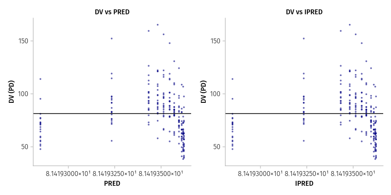

Figure 1: Indirect Response Model Type I: GOF Diagnostics

```julia
ind_insp = inspect(ind1_fit)
ind_insp_df = DataFrame(ind_insp)

# PD observations only
pd_obs = @rsubset(ind_insp_df, !ismissing(:dv_pd))

fig = Figure(size = (800, 400))

ax1 = Axis(fig[1, 1], xlabel = "PRED", ylabel = "DV (PD)", title = "DV vs PRED")
scatter!(ax1, pd_obs.dv_pd_pred, pd_obs.dv_pd, color = :navy, markersize = 5, alpha = 0.6)
ablines!(ax1, 0, 1, color = :black)

ax2 = Axis(fig[1, 2], xlabel = "IPRED", ylabel = "DV (PD)", title = "DV vs IPRED")
scatter!(ax2, pd_obs.dv_pd_ipred, pd_obs.dv_pd, color = :navy, markersize = 5, alpha = 0.6)
ablines!(ax2, 0, 1, color = :black)

fig
```

# 8 K-PD Models: PD Without PK Data

When PK data are unavailable (PD-only studies, retrospective analyses, sparse sampling), K-PD models use a **virtual compartment** to replace the PK model:

$$\frac{dA}{dt} = -K_{DE} \cdot A$$

where $A$ is the virtual drug amount and $K_{DE}$ is the apparent elimination rate ($= CL/V$). The drug effect is then driven by $K_{DE} \cdot A$ (analogous to $CL \cdot C_p$) rather than by concentration.

**Key parameters:**

- $K_{DE}$ = apparent elimination rate (replaces CL/V)
- $EDK_{50}$ = apparent potency (replaces $EC_{50}$; $EDK_{50} = EC_{50} \cdot CL$)

```julia
kpd_model = @model begin
    @param begin
        tvKDE   ∈ RealDomain(lower = 0.0, init = 0.1)
        tvEmax  ∈ RealDomain(lower = 0.0, init = 100.0)
        tvEDK50 ∈ RealDomain(lower = 0.0, init = 5.0)
        tvE0    ∈ RealDomain(init = 60.0)
        Ω       ∈ PDiagDomain(2)
        σ_pd    ∈ RealDomain(lower = 0.0, init = 5.0)
    end
    @random begin
        η ~ MvNormal(Ω)
    end
    @pre begin
        KDE   = tvKDE * exp(η[1])
        Emax  = tvEmax
        EDK50 = tvEDK50 * exp(η[2])
        E0    = tvE0
    end
    @dynamics begin
        A' = -KDE * A  # virtual compartment
    end
    @derived begin
        rate_out := @. KDE * A
        effect := @. E0 + Emax * rate_out / (EDK50 + rate_out)
        dv ~ @. Normal(effect, σ_pd)
    end
end
```

**Warning**

**K-PD limitations:**

- Assumes linear PK (first-order elimination)
- Cannot predict concentrations — only effects
- May overestimate IIV (conflates PK and PD variability)
- Requires ≥ 3 dose levels for identifiability
- Not recommended for regulatory submissions where PK data exist

# 9 The Four PD Paradigms: Decision Framework

When choosing a PD model structure, follow this decision tree:

| Question | If Yes → | If No → |
| --- | --- | --- |
| Is there a measurable delay between Cp and effect? | Effect compartment or IDR | Direct response |
| Does the drug affect a turnover process? | IDR (Types I–IV) | Effect compartment |
| Is the CE plot loop counter-clockwise? | Effect compartment (ke0) | Direct, tolerance, or IDR |
| Is PK data available? | PK-PD model | K-PD model |
| Is the effect reversible and dose-dependent? | Standard Emax/IDR | Consider more complex models |

# 10 PK-PD Modeling Steps

1. Develop and qualify the PK model first (using PK-only data)
2. Fix PK parameters and estimate PD parameters (sequential approach)
3. Or estimate PK and PD simultaneously (combined data approach — as shown above)
4. Evaluate GOF diagnostics for both PK and PD
5. Compare structural PD models (direct vs. effect compartment vs. indirect)

**Sequential vs. Simultaneous Estimation**

| Approach | Pros | Cons |
| --- | --- | --- |
| **Sequential** (fix PK, estimate PD) | Faster, PK model already validated | Ignores PK uncertainty, may bias PD estimates |
| **Simultaneous** (estimate PK + PD together) | Full uncertainty propagation, optimal use of data | Slower, larger parameter space, harder to converge |

**Recommendation:** Start sequential for model development (faster iteration), then switch to simultaneous for the final model.

# 11 Study Guide Questions

1. What is the difference between a direct and indirect PK-PD model?
2. When would you use an effect compartment model instead of a direct model?
3. What are the four types of indirect response models and how do they differ?
4. Why is Emax often fixed to 1 in indirect response models?
5. What are the advantages of simultaneous PK-PD estimation vs. sequential?
6. When would a K-PD model be appropriate instead of a full PK-PD model?
7. How does turnover half-life affect the time course of an indirect response?

# 12 Supplementary Material

| Topic | Tutorial | Key Additions |
| --- | --- | --- |
| **Lecture: Intrinsic CL & Enzyme Kinetics** | PK W7a | Vmax/KM enzyme kinetics — the pharmacological foundation of the Emax model |
| **Lecture: Clearance & Hepatic Extraction** | PK W6 | Drug elimination physiology underlying PK-PD model structure |
| **Lecture: Oral Absorption** | PK W8 | First-order absorption, bioavailability — the PK driving function for PD |
| PD model overview | [Introduction to PD Models](https://tutorials.pumas.ai/html/PDModels/00-introduction-to-pd-models.html) | Four PD paradigms, Emax/Hill curves, potency vs efficacy, decision flowchart |
| Direct response models | [Direct Response](https://tutorials.pumas.ai/html/PDModels/01-direct-response.html) | Stimulatory + inhibitory Emax, population simulation, full fitting workflow |
| Effect compartment models | [Effect Compartment](https://tutorials.pumas.ai/html/PDModels/02-effect-compartment.html) | Hysteresis visualization, ke0 sensitivity analysis, Cp vs Ce comparison, clinical examples |
| Indirect response models | [Indirect Response](https://tutorials.pumas.ai/html/PDModels/03-indirect-response.html) | All 4 IDR types with code, comparative simulation, turnover time sensitivity, clinical examples |
| K-PD models | [K-PD Models](https://tutorials.pumas.ai/html/PDModels/04-kpd-models.html) | Virtual compartment concept, KDE/EDK50 parameterization, limitations, K-PD vs PK-PD decision framework |
| Model selection | [PD Model Selection](https://tutorials.pumas.ai/html/PDModels/05-model-selection.html) | Systematic selection (EDA → mechanism → statistics), warfarin case study, common pitfalls |
| HCV viral dynamics | [HCV GSA](https://tutorials.pumas.ai/html/pkpd/hcvgsa.html) | QSP-style PK-PD with viral kinetics and global sensitivity analysis |
| TMDD models | [TMDD Foundations](https://tutorials.pumas.ai/html/tmdd/01-tmdd-foundations.html) → [TMDD Workflows](https://tutorials.pumas.ai/html/tmdd/05-tmdd-workflows.html) | Target-mediated drug disposition: full model, approximations, special cases |